# Hipotézisvizsgálat alapjai

Kovács László

2023. 05. 03.

## 1. A hipotézisvizsgálat alapgondolata

Istenigazából a **hipotézisvizsgálat** csak egy **alternatív mód a konfidencia-intervallumok mellett egy statisztikai mutatószám (paraméter) mintavételi hibájának figyelembe vételére**, amikor a mutatószám egy mintából számított értékéből akarjuk megismerni a valós, sokasági értékét. Azonban, a **hipotézisvizsgálat gondolatvilága a kérdést némileg eltérően közelíti meg, mint az eddig tanult konfidencia-intervallumok**.

Hipotézisvizsgálat során megfogalmazunk egy **állítást vagy szebb szóval hipotézist egy statisztikai mutatószám** (átlag, arány, medián, szórás, stb.) **valós, sokasági értékéről, és utána megpróbáljuk állítani, hogy ezt a felvetést/hipotézist a megfigyelt mintaadatok alátámasztják-e vagy sem**. Most így alapesetben a paraméteres statisztikai hipotézisvizsgálatokat vagy rövidebben az úgynevezett **paraméteres (statisztikai) próbákat vizsgáljuk**, mert a **megfogalmazott hipotézisünk mindig egy statisztikai paraméter** (azaz statisztikai mutatószám) valós, **sokasági értékéről szól** majd egyelőre.

Nézzünk meg **ismét egy $n=100$ elemű FAE mintát a 2022-es Balaton átúszást teljesítők sokaságából** a LIDLBalaton2022.xlsx fájl alapján.  
Ahogy a 3. heti tananyagban is néztük, ebben a fájlban a Balaton átúszás résztvevőinek *neve, neme és percben mért időeredménye* található. Ez az adatsor lesz most is a **sokaságunk**.

```python
# Elemzéshez és ábrázoláshoz szükséges csomagok betöltése
import numpy as np
import pandas as pd
import matplotlib.pyplot as plt
import scipy.stats as stats

# Adatbeolvasás data frame-be
Balcsi = pd.read_excel("LIDLBalaton2022.xlsx")

Balcsi.info()
```

```
## <class 'pandas.core.frame.DataFrame'>
## RangeIndex: 9751 entries, 0 to 9750
## Data columns (total 3 columns):
##  #   Column  Non-Null Count  Dtype
## ---  ------  --------------  -----
##  0   Nev     9751 non-null   object
##  1   Nem     9751 non-null   object
##  2   PERC    9751 non-null   float64
## dtypes: float64(1), object(2)
## memory usage: 228.7+ KB
```

Szuper, vegyük is ki azt az $n=100$ elemű FAE mintát! Rögzítsük meg a `random_state` paraméter $1992$-nek, hogy mindannyian ugyan azt a $100$ elemű véletlen mintát kapjuk!

```python
BalcsiMinta = Balcsi.sample(n = 100, replace = True, random_state = 1992)

BalcsiMinta.info()
```

```
## <class 'pandas.core.frame.DataFrame'>
## Int64Index: 100 entries, 7991 to 5727
## Data columns (total 3 columns):
##  #   Column  Non-Null Count  Dtype
## ---  ------  --------------  -----
##  0   Nev     100 non-null    object
##  1   Nem     100 non-null    object
##  2   PERC    100 non-null    float64
## dtypes: float64(1), object(2)
## memory usage: 3.1+ KB
```

Namármost. A **teljes sokaság átlagos átúszási idejéről $6$ db különböző állítást tudok megfogalmazni** egy konkrét érték, pl. az $2.5$ óra, azaz $150$perc viszonylatában. A valós, sokasági átlagos időeredményt most is $\mu$-vel jelöljük:

1. Optimista vagyok, és azt mondom, hogy gyorsak voltak a népek és az átlagos átúszási idő a sokaságban kisebb, mint $150$ perc: $\mu < 150$
2. Pesszimista magyarként azt is mondhatom, hogy lassú volt az úszótömeg és az átlagos időeredmény a sokaságban nagyobb, mint $150$ perc: $\mu > 150$
3. De még azt is el tudom képzelni, hogy a valós átlag úszási idő épp $150$ perc: $\mu = 150$
4. Vagy abban is hihetek, hogy a sokaságban az átlag időeredmény minden csak nem $150$ perc: $\mu \neq 150$
5. A *félig optimista* mondhatja azt, hogy a sokasági átlagos időeredmény *legfeljebb* $150$ perc: $\mu \leq 150$
6. Kizárásos alapon a *félig pesszimista* pedig úgy fog vélekedni, hogy a sokasági átlagos úszási idő *legalább* $150$ perc: $\mu \geq 150$

Oké, akkor van $6$ db elméletem…azaz *hipotézis*em. Nézzük meg mennyi az **átlag a megfigyelt $100$ elemű mintában**:

```python
BalcsiMinta.PERC.mean()
```

```
## 164.44033333333334
```

No, a megfigyelt $100$ átúszó alapján a mintaátlag kb. $164$ perc. Ez alapján a 2. állítás, a pesszimista ürge mondása tűnik igaznak, az **átlag nagyobb, mint** $150$ perc. NODE! **Amit itt látunk az csak $100$ ember átlagos ideje, a teljes sokaságban az átlagos átúszási idő ettől eltérhet!**  
Szebben fogalmazva, **a $164$ és $150$ közti különbség simán betudható a mintavételi hibának is!!**  
**Ezért végzünk hipotézisvizsgálatot**, hogy eldöntsük, hogy a $\mu > 150$ hipotézis (állítás) igaznak vehető-e még a mintavételi hibával együtt is.

Igazából, ha belegondolunk, akkor mind a $6$ állítás visszavezethető ahhoz a kérdéshez, hogy a valós, sokasági átlag, $\mu$ **eltér-e** annyira a $150$-től, hogy az **eltérés már meghaladja a mintavételi hibát**. Ezt úgy mondjuk szépen, hogy **azt vizsgáljuk, SZIGNIFIKÁNS-e az eltérés a valós $\mu$ és $150$ között!**

Most itt éppen ki tudjuk számolni a teljes sokaság ismeretében, hogy $\mu=167$ perc, ami **tényleg magasabb, mint** $150$.

```python
Balcsi.mean()
```

```
## PERC    167.529141
## dtype: float64
##
```

A **gyakorlatban viszont mindezt NEM tudjatjuk, hiszen csak az $n=100$ elemű minta áll rendelkezésünkre!!** Szóval **marad az, hogy hipotézisvizsgálattal ellenőrizzük, hogy a $\bar{y}=164$ megfigyelt mintaátlag szignifikánsan eltér-e a $150$-től**.

Az eddigi logikánk alapján létre tudunk hozni egy úgynevezett **nullhipotézist** ($H_0$) és **alternatyv hipotézist** ($H_1$) az **eredeti állításunkból**.

A pontos logika itt a következő. A $H_0$-ban mindig olyan állítást fogalmazunk meg, ami **a vizsgált statisztikai paraméter tekintetében megengedi az egyenlőséget**.  
A $H_1$ pedig az **eredeti állítástól függ**:

- Ha az **eredeti állítás megengedi az egyenlőséget**, akkor az állítás $H_0$-ba kerül és **a $H_1$-ben tagadjuk az eredeti állítást**. Ebből adódóan azt várjuk, hogy a hipotézisvizsgálat végén **a $H_0$ állítás bizonyuljon igaznak**. Ebben az esetben azt szeretnénk, hogy **a valós sokasági átlag átúszási idő ne különbözzön szignifikánsan a $150$ perctől**.
- Ha az **eredeti állítás nem engedi meg az egyenlőséget**, akkor az a $H_1$-be “költözik”, és **a $H_0$-ban az eredeti állítást tagadjuk**. Ebből adódóan azt várjuk, hogy a hipotézisvizsgálat végén **a $H_1$ állítás bizonyuljon igaznak**. Ebben az esetben azt szeretnénk, hogy **a valós sokasági átlag átúszási idő szignifikánsan különbözzön a $150$ perctől**.

Ezen elveket figyelembe véve a $6$ eredeti állításunkhoz a következő $H_0$ és $H_1$ párok adhatók meg:

1. Állítás: $\mu < 150$ || $H_0:\mu \geq 150$ || $H_1:\mu < 150$ || Állítás a $H_1$-ben található.
2. Állítás: $\mu > 150$ || $H_0:\mu \leq 150$ || $H_1:\mu > 150$ || Állítás a $H_1$-ben található.
3. Állítás: $\mu = 150$ || $H_0:\mu = 150$ || $H_1:\mu \neq 150$ || Állítás a $H_0$-ban található.
4. Állítás: $\mu \neq 150$ || $H_0:\mu = 150$ || $H_1:\mu \neq 150$ || Állítás a $H_1$-ben található.
5. Állítás: $\mu \leq 150$ || $H_0:\mu \leq 150$ || $H_1:\mu > 150$ || Állítás a $H_0$-ban található.
6. Állítás: $\mu \geq 150$ || $H_0:\mu \geq 150$ || $H_1:\mu < 150$ || Állítás a $H_0$-ban található.

Az 1-2. és 5-6 állításokban, ahol **nem “tiszta” egyenlőség van $H_0$-ban szoktunk úgynevezett technikai nullhipotézist, $H_0^T$-t alkalmazni**. Ez csak annyit jelent, hogy a **nem “tiszta” egyenlőséggel adott $H_0$-t átírjuk tiszta egyenlőségre**.  
Tehát, pl. az **1. és 5. állítás technikai nullhipotézissel**:

1. Állítás: $\mu < 150$ || $H_0^T:\mu = 150$ || $H_1:\mu < 150$ || Állítás a $H_1$-ben található.
2. Állítás: $\mu \leq 150$ || $H_0^T:\mu = 150$ || $H_1:\mu > 150$ || Állítás a $H_0$-ban található.

A hipotézisvizsgákat vagy más néven **statisztikai próbákat a $H_1$-ben adott relációs jeleik alapján három csoportba kategórizálják**:

- Ha $H_1$-ben $\neq$ jel van, akkor **kétoldali próba**
- Ha $H_1$-ben $<$ jel van, akkor **baloldali próba**
- Ha $H_1$-ben $>$ jel van, akkor **jobboldali próba**

### 1.1. A p-érték fogalma

Ha szépenfelírtuk a megfelelő $H_0$ és $H_1$ párokat, akkor meghatározzuk, hogy a megfigyelt mintánk alapjánk melyik tekinthető igaznak a kettő közül. Erre a célra egy **p-érték nevű statisztikai mutatószámot használunk**. A **p-érték megadja mekkora a valószínűsége, hogy a $H_0$ elutasításával hibás döntést hozunk**  
Szóval, ha azt kapom, hogy **p-érték = 30%**, akkor azt mondhatom, hogy **30% valószínűséggel HIBÁZOM, ha azt mondom, hogy $H_0$ egy hamis állítás a mintánk alapján**.

Ez alapján a **döntési szabály** $H_0$ és $H_1$ között a következő. Amennyiben a **p-érték túl magas, elfogadjuk** $H_0$-t, mivel elutasítása túl nagy hibavalószínűséggel járna. Ellenben ha a **p-érték túl alacsony**, akkor elutasítjuk $H_0$-t és **elfogadjuk** $H_1$**-et**, mivel $H_0$ elutasítása nagyon alacsony hibavalószínűséggel jár.

A kérdés az hogyan döntöm el, hogy egy p-érték túl magas/alacsony-e? Erre van nekünk az úgynevezett **szignifikancia-szint, amit** $\alpha$**-val jelölünk**. A szignifikancia-szint a **maximális elfogadott hibavalószínűség $H_0$ elutasításához**.

Tehát, ha azt mondjuk, hogy $\alpha=5\%$, akkor $5\%$ alatti p-érték esetén **elutasítjuk $H_0$-t, mivel elutasítása kisebb hibával jár, mint a megengedett maximum**. Másrészről, ha a p-értékünk $5\%$ feletti, akkor meg **elfogadjuk $H_0$-t, mivel elutasítása nagyobb hibával jár, mint a megengedett maximum**.

Ezen a ponton tehát a **következőt hinnénk**:

- **p-érték** $>\alpha \rightarrow H_0$
- **p-érték** $\leq\alpha \rightarrow H_1$

Szóval, az előbbi családregényünk alapján az tűnik egy normálisabb megoldásnak, ha **azt mondjuk, hogy $1\%$ és $10\%$ közti p-érték esetén nem választunk $H_0$ és $H_1$ között, mert ekkor a döntésünk nagyon érzékeny lenne a konkrét $\alpha$ megválasztására**  
Ha egy $1\%$ és $10\%$ közti p-értéket produkálnak a mintaadataink, akkor a legjobb, amit tehetünk, hogy **addig növeljük a mintaméretet ($n$-t) amíg a p-érték egyértelműen $1\%$ alá vagy $10\%$ fölé nem kerül**. Ezt a módszert hívja a statisztika [szekvenciális analízisnek](https://en.wikipedia.org/wiki/Sequential_analysis), és a klinikai gyógyszerkísérletekben és az ipari minőségbiztosításban rendszeresen alkalmazzák. A módszer alapjait pedig egy [Wald Ábrahám](https://hu.wikipedia.org/wiki/Wald_%C3%81brah%C3%A1m) nevű magar statisztikus dolgozta ki az Amerikai Légierőnek a II. világháború alatt (zsidó származása miatt itthon “nem kellett”). Szóval, mint minden fontos területet a világon, ezt is magyarok találták ki. :) #Jézusmagyarvót

Tehát, az egy fokkal **korrektebb döntés szabályok hipotézisvizsgálat esetén**:

- **p-érték** $>10\% \rightarrow H_0$
- $1\% <$ **p-érték** $\leq 10\% \rightarrow$ **nincs döntés**
- **p-érték** $\leq1\% \rightarrow H_1$

További fejfájásokat okoz, hogy nagyon óvatosan kell bánni az $1\%$ és $10\%$ közti p-értékkel azért is, mert a **p-érték és az $\alpha$ csak egy nézőpontból írják le a hipotézisvizsgálat során elkövethető döntési hibát**! A **p-érték és az $\alpha$ csak az úgyenevzett ELSŐFAJÚ hibáról ad információt: a valóságban igaz $H_0$ elutasításának valószínűségéről**!  
NODE, van nekünk **MÁSODFAJÚ hibánk is**, ami a **valóságban hamis $H_0$ téves elfoggadását jelenti**. Az a rossz hír, hogy ennek a **másodfajú hibának a valószínűségét nem tudjuk kiszámolni a megfigyelt minta alapján!!**  
Ez a hipotézoisvizsgálat nagy átka: ha **elfogadunk egy $H_0$-t, akkor igazából nem tudjuk, hogy mekkora valószínűséggel hibázunk, csak azt tudjuk, hogy mennyi a $H_0$ elutasításának hibavalószínűsége, mert ez pont a p-érték**.  
Ezért nagyon sokan fogalmaznak szándékosan ilyen furán a $H_0$-ról, hogy nem elfogadjuk a $H_0$-t, hanem **nem tudjuk elutasítani a $H_0$-t**.

A probléma alaposabb megértésében szerintem remek szolgálatot tesz az alábbi mém. :)

[figure not shown]

Most pedig nézzük meg **hogyan kell kiszámolni a p-értéket a megfigyelt minta alapjánabban az esetben, amikor a vizsgált statisztikai paraméter az átlag**, azaz $\mu$!

## 2. A sokasági átlagra vonatkozó *t-próba*

A p-érték számításához **mindig szükségünk van egy próbafüggvény nevű statisztikai mutatóra, amit csak a megfigyelt mintaadatokból ki tudunk mindig számolni**. Eztán a **p-értéket a próbafüggvényből egy nevezetes valószínűségi eloszlás (standard normális, t-eloszlás, khi-négyzet, stb.) alapján tudjuk kiszámolni**.

Jelöljük a **sokasági átlag HIPOTETIKUS értékét** $\mu_0$-nak. Ez az érték, amit az állításban **feltételezek** a valós, sokasági átlagról. Az 1. fejezetben ez volt a $150$ perc. Ezzel a jelöléssel az alábbi módon néz ki az átlagra vonatkozó próbafüggvény:
$$\frac{\bar{y}-\mu_0}{\frac{s}{\sqrt{n}}}$$

Tehát, a próbafüggvényünk most nem más, mint a **minta és hipotetikus átlag különbsége osztva az átlag standard hibájával**.

Ha a $H_0$-ban jól okoskodunk, és **tényleg sikerült a valós $\mu$ sokasági átlagot venni a $\mu_0$ elvi** (hipotetikus) **átlagnak, akkor sok-sok mintavétel esetén a próbafüggvényünk $n-1$ szabadságfokú t-eloszlást követ**:
$$\frac{\bar{y}-\mu}{\frac{s}{\sqrt{n}}} \sim t(n-1)$$

A képlet mögött az az elv nyugszik, hogy **a $\mu = \mu_0$ technikai nullhipotézist ($H_0^T$) alkalmazzuk mind a 6 különböző típusú $H_0$ és $H_1$ párosnál, így meg tudjuk majd adni a próbafüggvény eloszlását sok-sok mintavétel esetén**.

Ezt az egészet gyorsan ellenőrizni tudjuk, ha **kiveszünk $10000$ db $n=100$ elemű FAE mintát a Balaton átúszók sokaságából**, ahogy a 3. heti tananyagban is tettük.  
Most csak **visszatöltjük a $10000$ db FAE mintát tartalmazó Excel táblát egy data frame-be**, amit a 2. heti tananyagban hoztunk létre. Ez az Excel fájl [innen](https://github.com/KoLa992/Statisztika-II-Python-Jegyzet/blob/main/MintaDataFrame.xlsx) elérhető.

```python
MintaVetelek100Elem = pd.read_excel("MintaDataFrame.xlsx")
MintaVetelek100Elem
```

```
##            Elem1       Elem2       Elem3  ...      Elem98      Elem99     Elem100
## 0     164.800000  129.066667  156.166667  ...  207.350000  159.666667  165.883333
## 1     152.516667  212.483333  152.900000  ...  307.266667  119.783333  128.216667
## 2     145.666667  185.266667  169.516667  ...  167.733333  228.366667  215.633333
## 3     185.683333  120.333333  201.250000  ...  182.766667  177.666667  112.450000
## 4     117.483333  142.350000  320.266667  ...  188.566667  189.166667   99.916667
## ...          ...         ...         ...  ...         ...         ...         ...
## 9995  162.333333   83.350000  146.750000  ...  164.250000  131.933333  128.183333
## 9996  100.416667  161.433333  187.366667  ...  160.483333  168.416667  209.300000
## 9997  146.450000  160.783333  165.483333  ...  158.816667  167.733333  183.400000
## 9998  139.250000  140.466667  130.933333  ...  153.616667  112.366667  196.050000
## 9999  147.316667  173.450000  106.100000  ...  185.616667  171.800000  135.166667
##
## [10000 rows x 100 columns]
```

Oké, az eredményből látjuk is, hogy úgy néz ki a data frame, hogy **1 sor tartalmaz 1 db 100 elemű mintát és a mintaelemeket** (tehát a mintába besorsolt versenyző percben mért időeredményét) **az oszlopkban tároljuk**.

Kiszámoljuk mindenegyes mintavételre a minta átlagos időeredményét és azok korrigált szórását. Csak figyeljünk, hogy az alkalmazott `numpy` függvényeket `axis = 1` paraméterrel használjuk, hogy ne oszlopok, hanem sorok szerint vegyék az átlagokat és a szórásokat. Plusz, figyeljünk, hogy a függvényeket minidg csak az első $100$ oszlopra engedjük rá, hiszen ott vannak a tényleges mintaelemek. Ezt ugyebár a data framek `iloc` metódusával tudjuk biztosítani, ahogy a 3. heti tananyag 2. fejezetében csináltuk.

```python
MintaVetelek100Elem['Atlagok'] = np.mean(MintaVetelek100Elem.iloc[:,0:100], axis=1)
MintaVetelek100Elem['Szorasok'] = np.std(MintaVetelek100Elem.iloc[:,0:100], axis=1, ddof=1)

MintaVetelek100Elem
```

```
##            Elem1       Elem2       Elem3  ...     Elem100     Atlagok   Szorasok
## 0     164.800000  129.066667  156.166667  ...  165.883333  171.261667  42.397078
## 1     152.516667  212.483333  152.900000  ...  128.216667  158.026500  44.288357
## 2     145.666667  185.266667  169.516667  ...  215.633333  172.278833  44.809282
## 3     185.683333  120.333333  201.250000  ...  112.450000  163.434167  45.453383
## 4     117.483333  142.350000  320.266667  ...   99.916667  166.552833  45.814202
## ...          ...         ...         ...  ...         ...         ...        ...
## 9995  162.333333   83.350000  146.750000  ...  128.183333  163.682333  41.282298
## 9996  100.416667  161.433333  187.366667  ...  209.300000  164.332833  42.020990
## 9997  146.450000  160.783333  165.483333  ...  183.400000  163.702333  37.947348
## 9998  139.250000  140.466667  130.933333  ...  196.050000  166.423833  39.749948
## 9999  147.316667  173.450000  106.100000  ...  135.166667  173.050333  48.227237
##
## [10000 rows x 102 columns]
```

Ezek után pedig **ki tudjuk számolni a próbafüggvényünket egy olyan $H_0$ és $H_1$ párosra, amiről tudjuk, hogy a sokaságban $H_0$ igaz, és egy olyanra, ahol tudjuk, hogy a sokaságban $H_0$ hamis**:

- **IGAZ** $H_0$ esete: $H_0:\mu=167$ és $H_1: \mu < 167$
- **HAMIS** $H_0$ esete: $H_0^T:\mu=150$ és $H_1: \mu > 150$

```python
mu_0_igaz = np.mean(Balcsi.PERC) # ez ekkor a valós sokasági átlag
mu_0_hamis = 150 # tetszőleges érték
n = 100 # mintaméret

MintaVetelek100Elem['ProbaFv_H0Igaz'] = (MintaVetelek100Elem.Atlagok - mu_0_igaz)/(MintaVetelek100Elem.Szorasok/np.sqrt(n))
MintaVetelek100Elem['ProbaFv_H0Hamis'] = (MintaVetelek100Elem.Atlagok - mu_0_hamis)/(MintaVetelek100Elem.Szorasok/np.sqrt(n))

MintaVetelek100Elem
```

```
##            Elem1       Elem2  ...  ProbaFv_H0Igaz  ProbaFv_H0Hamis
## 0     164.800000  129.066667  ...        0.880373         5.014890
## 1     152.516667  212.483333  ...       -2.145630         1.812327
## 2     145.666667  185.266667  ...        1.059980         4.971924
## 3     185.683333  120.333333  ...       -0.900917         2.955592
## 4     117.483333  142.350000  ...       -0.213101         3.613035
## ...          ...         ...  ...             ...              ...
## 9995  162.333333   83.350000  ...       -0.931830         3.314334
## 9996  100.416667  161.433333  ...       -0.760645         3.410875
## 9997  146.450000  160.783333  ...       -1.008452         3.610880
## 9998  139.250000  140.466667  ...       -0.278065         4.131787
## 9999  147.316667  173.450000  ...        1.144829         4.779526
##
## [10000 rows x 104 columns]
```

Okké! Akkor miután megvannak a kétféle esetben a próbafüggvényeink, **nézzük meg a kétféle próbafüggvények hisztogramja a $10000$ db mintavétel alapján hogyan alakul a $t(n-1)$, azaz $t(100-1)$ eloszlás sűrűségfüggvényéhez** képest.  
A sűrűségfüggvény hisztogramhoz való illeszkedését ábrázoló kód teljes mértékben az 1. heti tananyag 2.3. és 3. fejezeteiben lévő kódok logikáját követi.

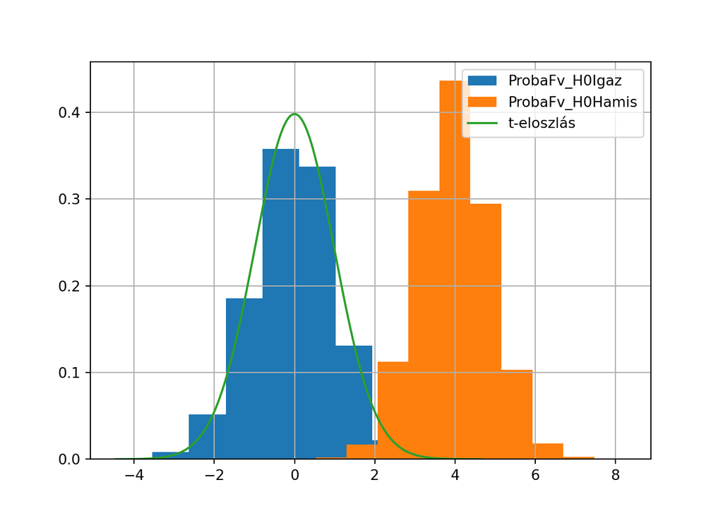

```python
# Igaz és Hamis H0 esetén próbafüggvények kisztogramja
# A 'label' paraméter majd a színfeliratokat adja az ábrán
MintaVetelek100Elem.ProbaFv_H0Igaz.hist(density = True, label="ProbaFv_H0Igaz")
MintaVetelek100Elem.ProbaFv_H0Hamis.hist(density = True, label="ProbaFv_H0Hamis")
# A sűrűségfüggvény x tengelye az Igaz H0 esetén vett próbafüggvények min-max tartományában lesz az 'x' tengelyen
x_tengely = np.arange(np.min(MintaVetelek100Elem.ProbaFv_H0Igaz), np.max(MintaVetelek100Elem.ProbaFv_H0Igaz), 0.01)
# A t-eloszlású sűrűségfüggvény (pdf) értékek az 'y' tengelyen
y_tengely = stats.t.pdf(x_tengely, df = n-1)
# Sűrűségfüggvény felrakása a hisztogramra
plt.plot(x_tengely, y_tengely, label = "t-eloszlás")
# Színfeliratok megjelenítése a jobb felső sarokban
plt.legend(loc="upper right")
# Ábra mutatása
plt.show()
```

Szuper! Tehát **igaz $H_0$ esetén tényleg t-eloszlást követ a próbafüggvény a sok-sok mintavételünk esetén**. Hamis $H_0$ esetén pedig valami más szimmetrikus eloszlás rajzolódik ki a hisztogramon, ami NEM a t-eloszlás. De hogy ez most konkrétan mi, nem annyira érdekel minket. :)

Ebből, hogy a próbafüggvény t-eloszlást követ sok-sok mintavétel esetén, ha $H_0$ igaz, **ki tudjuk számolni a p-értéket**. gyakorlatilag területeket számolunk a *t-eloszlás* sűrűségfüggvénye alatt. A konkrét számoláshoz végig kell gondolnunk, hogy **mi a legjobb eset $H_0$ szempontjából a próbafüggvényre nézve**:

- **Kétoldali** próbák ($H_0: \mu=\mu_0$ és $H_1: \mu \neq \mu_0$) esetén: ha a **próbafüggvény pontosan** $0 \rightarrow$ ez az elvi eset arra utal, hogy a hipotetikus átlag és a valós, sokasági átlag ugyanaz, így a $H_1$ $0$ valószínűséggel következik be.
- **Baloldali** próbák ($H_0: \mu\geq\mu_0$ és $H_1: \mu < \mu_0$) esetén: ha a **próbafüggvény =** $+\infty \rightarrow$ ez az elvi eset arra utal, hogy a sokasági átlag ($\mu$) az pont $+\infty$, aminél minden $\mu_0$ kisebb, így a $H_1$ $0$ valószínűséggel következik be.
- **Jobboldali** próbák ($H_0: \mu=\mu_0$ és $H_1: \mu > \mu_0$) esetén: ha a **próbafüggvény =** $-\infty \rightarrow$ ez az elvi eset arra utal, hogy a sokasági átlag ($\mu$) az pont $-\infty$, aminél minden $\mu_0$ nagyobb, így a $H_1$ $0$ valószínűséggel következik be.

Ez alapján,ha **van egy ismert próbafüggvény értékem, amit $t$-vel jelölök, akkor a p-érték a $t(n-1)$ eloszlásból az alábbi ábrán látható módon számítható ki**:

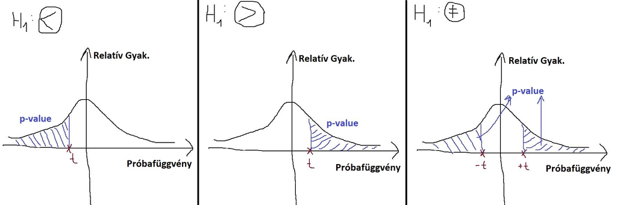

Látható, hogy **mindhárom esetben a p-érték úgy lesz kiszámolva, hogy ha a konkrét $t$ próbafüggvényünk messzebb kerül a $H_0$ számára legjobb esettől, akkor a p-érték csökken $\rightarrow$ hiszen egyre kisebb és kisebb hibát vétünk, ha elutasítjuk a $H_0$-t!!**

Mindezek alapján akkor **számoljuk ki** a `scipy` csomag `stats.t.cdf` függvénye segítségével a **p-értéket mind a $10000$ db mintában a korábban vizsgált két $H_0$ és $H_1$ párunkra, ahol egyszer igaz, egyszer pedig hamis volt a** $H_0$:

- **IGAZ** $H_0$ esete: $H_0:\mu=167$ és $H_1: \mu < 167$
- **HAMIS** $H_0$ esete: $H_0:\mu=150$ és $H_1: \mu > 150$

Figyeljünk arra, hogy az $1-$ rész a `stats.t.cdf` függvényen a hamis $H_0$ esetben a **jobboldali próba** miatt van:

```python
n = 100 # mintaméret

MintaVetelek100Elem['p_ertek_H0Igaz'] = stats.t.cdf(MintaVetelek100Elem.ProbaFv_H0Igaz, df = n-1)
MintaVetelek100Elem['p_ertek_H0Hamis'] = 1-stats.t.cdf(MintaVetelek100Elem.ProbaFv_H0Hamis, df = n-1)

MintaVetelek100Elem
```

```
##            Elem1       Elem2  ...  p_ertek_H0Igaz  p_ertek_H0Hamis
## 0     164.800000  129.066667  ...        0.809605         0.000001
## 1     152.516667  212.483333  ...        0.017174         0.036483
## 2     145.666667  185.266667  ...        0.854133         0.000001
## 3     185.683333  120.333333  ...        0.184909         0.001950
## 4     117.483333  142.350000  ...        0.415843         0.000239
## ...          ...         ...  ...             ...              ...
## 9995  162.333333   83.350000  ...        0.176846         0.000642
## 9996  100.416667  161.433333  ...        0.224338         0.000469
## 9997  146.450000  160.783333  ...        0.157848         0.000241
## 9998  139.250000  140.466667  ...        0.390771         0.000038
## 9999  147.316667  173.450000  ...        0.872480         0.000003
##
## [10000 rows x 106 columns]
```

Remek! Az első és az utolsó $5$ db minta alapján az elvárt eredményeket kaptuk a p-értékekre: magas értékek igaz $H_0$, alacsony értékek hamis $H_0$ esetén. Pontosabb értelmezéshez nézzük meg **az $5.$, azaz a data frame-ben $4$-es sorindexszel rendelkező minta esetét**:

- **Igaz $H_0$ esetén $41.58\%$-os valószínűséggel hibázunk, ha elutasítjuk $H_0$-t ezen minta alapján**.
- **Hamis $H_0$ esetén $0.02\%$-os valószínűséggel hibázunk, ha elutasítjuk $H_0$-t ezen minta alapján**.

Ugyanakkor a $2.$ mintában látjuk, hogy a p-érték csak $1.7\%$ igaz $H_0$ és $3.6\%$ hamis $H_0$ esetén. Szóval, a **“nem hozunk döntést, ha a p-érték $1\% - 10\%$ között mozog”, egy elég jogos szabálynak tűnik**! :)

Hasonlóan megerősíti az $1\% - 10\%$ közötti p-értékek esetén vett óvatosságot, ha az igaz és hamis $H_0$ esetén vizsgált p-értékeket doboz ábrán vizsgáljuk:

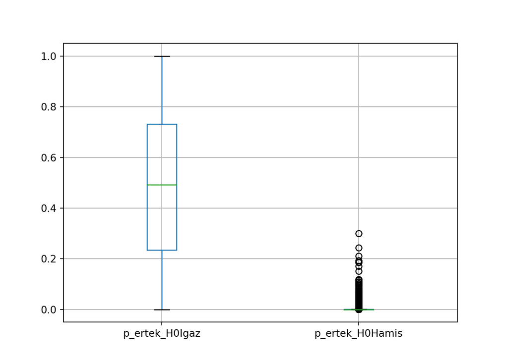

```python
MintaVetelek100Elem.boxplot(column=['p_ertek_H0Igaz', 'p_ertek_H0Hamis'])
plt.show()
```

Ahogyan vártuk is, igaz $H_0$ esetén a p-értékek középső $50\%$-a, azaz interkavrtilis trejedelme ($IKT$) látványosan magasabban van, mint hamis $H_0$ esetében. Ugyanakkor, azt is nagyon fontos látni az ábrán, hogy **a nagy p-értékek kilógó értéknek számítanak hamis $H_0$ esetén, de a kis p-értékek nem kilógó értékek igaz $H_0$ esetében!** Tehát, néha megérheto szigorúbb $\alpha$-t használni, mint $1\%$. Sokan csak akkor utasítják el $H_0$-t, ha a p-érték kisebb, mint $0.1\%=0.001$, szóval $\alpha=0.001$ mellett dolgoznak.

### 2.1. A *t-próba* beépített függvénnyel

Azért van némi szerencsénk, mert az **átlagra vonatkozó t-próba p-értékét szépen ki lehet számolni beépített `scipy` függvénnyel** is!

Vegyük például az 1. fejezet elején kivett $n=100$ elemű mintát, amit a `BalcsiMinta` című Python objektumban tároltunk le, ami egy $100\times3$-as data frame:

```python
BalcsiMinta.info()
```

```
## <class 'pandas.core.frame.DataFrame'>
## Int64Index: 100 entries, 7991 to 5727
## Data columns (total 3 columns):
##  #   Column  Non-Null Count  Dtype
## ---  ------  --------------  -----
##  0   Nev     100 non-null    object
##  1   Nem     100 non-null    object
##  2   PERC    100 non-null    float64
## dtypes: float64(1), object(2)
## memory usage: 3.1+ KB
```

Vizsgáljuk meg ezen a mintán az alábbi $H_0$ és $H_1$ párost:

- $H_0^T:\mu=150$
- $H_1 > 150$

Mivel $H_1$-ben $>$ relációs jel lakik, így **jobboldali** lesz a hipotézisvizsgálat.  
Tudjuk, hogy itt **a $H_1$ lesz igaz, hiszen láttuk korábban, hogy a teljes sokaságban az átlagos átúszási idő $167.5$ perc**. Tehát, valami **jó alacsony p-értéket várunk**!

Ez szépen ki is jön manuálisan is! Először kiszámoljuk a $\frac{\bar{y}-\mu_0}{\frac{s}{\sqrt{n}}}$ **próbafüggvényt** $\mu_0=150$ mellett, hiszen a hipotézisekben azt nézzük, hogy a valós, sokasági átlag szignifikánsan nagyobb-e, mint ez a feltételezett (hipotetikus) $150$ perces átlag.

```python
elviátlag = 150
mintaátlag = np.mean(BalcsiMinta.PERC)
s = np.std(BalcsiMinta.PERC, ddof=1)
n = len(BalcsiMinta)

próbafv = (mintaátlag - elviátlag) / (s/np.sqrt(n))
próbafv
```

```
## 3.7195426048126436
```

Remek! Ebből gyorsan is meg is van a $t(n-1)$ eloszlásból (`stats.t.cdf` függvénnyel) a p-érték. Most ugye a **próbafüggvény felé esés valószínűségét számoljuk, hiszen jobboldali a próba**.

```python
p_ertek_t_elo = 1 - stats.t.cdf(próbafv, df = n-1)
p_ertek_t_elo * 100 # százalékban írom ki
```

```
## 0.01655831079531156
```

A **p-érték alapján elmonható, hogy a most vizsgált $100$ elemű minta alapján csak $0.017\%$ a valószínűsége a hibának, ha $H_0$-t elutasítjuk**. Ez **kisebb még a legkisebb szokásos szignifikancia-szintnél, az $\alpha=1\%$-nál is, így meghozzuk ezt a döntést és $H_0$-t elutasítjuk**.  
Ez alapján pedig $H_1$ elfogadható, azaz a **sokaságban az átlagos átúszási idő szignifikánsan** (mintavételi hibát meghaladó mértékben) **nagyobb, mint $150$ perc**.  
Most tudjuk, hogy **helyesen döntöttünk**, mivel láttuk, hogy a sokaságban az átlagos átúszási idő $167.5$ perc.

Mindez szerencsére elintézhető a `scipy` csomag `stats.ttest_1samp` függvényével is. Ha a függvény

- első paraméterében megadjuk az aktuális mintánk elemeit tartalmazó oszlopot egy data frame-ből,
- második paraméterben az elvi átlagot, azaz $\mu_0$-t,
- az `alternative` paraméterben pedig a próba oldalát $H_1$ relációs jele alapján
  - lehetséges értékek: `‘two-sided’, ‘less’, ‘greater’`, rendre a $\neq$, $<$, $>$ relációs jeleket jelölik $H_1$-ben

Akkor a **függvény megadja a t-próba p-értékét és a próbafüggvényt is**:

```python
stats.ttest_1samp(BalcsiMinta.PERC, 150, alternative='greater')
```

```
## Ttest_1sampResult(statistic=3.7195426048126436, pvalue=0.00016558310795314698)
```

Szuper, ugyan úgy megvan a próbafüggvény ($3.7195$) és a $0.017\%$-os p-érték is! :)

### 2.2. A *t-próba* előfeltételei

Természetesen, ennek a t-próbás hipotézisvizsgálatnak is vannak előfeltételei, mint ahogy a különböző konfidencia-intervallum képleteknek is voltak. **Ha ezek a feltételek nem teljesülnek, akkor bármi is jött ki p-értékre, azt nem használhatjuk döntésre $H_0$-ról és $H_1$-ről**, hiszen az alkalmazott képletek mögötti követelmények az adatokal szemben NEM teljesülnek.

A t-próbának alapvetően **két feltétel**ére kell odafigyelni:

1. Amennyiben **kis mintánk** ($n\leq30$) van, akkor feltesszük, hogy **az adatok, amikből a mintát vettük normális eloszlást követnek**
2. Ha a **minta elemszáma nagy** ($n>30$), akkor **nem kell semmi extra előfeltételre figyelni**.

Most az $n=100$ elemű mintánk a Balaton átúszók sokaságából nagy minta, hiszen $100>30$, de azért nézzünk rá az **időeredmény adatok eloszlására a minta alapján**:

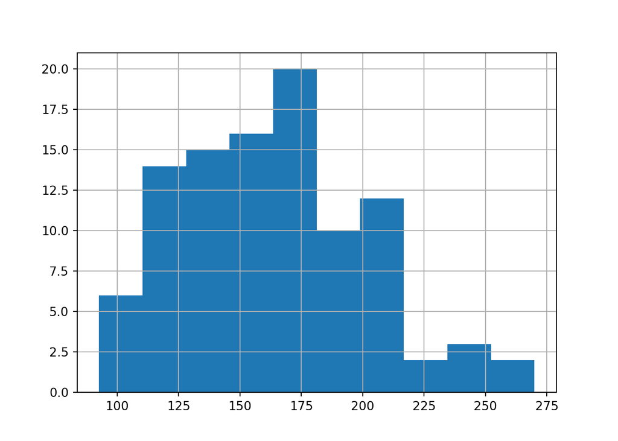

```python
BalcsiMinta.PERC.hist()
plt.show()
```

Hm, bár a nagy mintaelemszám miatt ez nem számít, de azért megnyugtató, hogy az átúszási idők eloszlása nem olyan durván tér el a normális eloszlás sűrűségfüggvényétől. Csak nagyon enyhén van egy kis jobbra elnyúló jellege, de semmi vészes. :)

## 3. A sokasági átlagra vonatkozó *z-próba*

Ugyebár az átlagra vonatkozó konfidencia-intervallumok esetén megfigyeltük, hogy **nagy szabadságfok ($df>30$) esetén a t-eloszlás lényegében megegyezik a standard normális eloszlással**.

Azaz, kicsit matekosabban fogalmazva: **ha $n >30$, akkor igaz nullhipotézis ($H_0$) esetén** (tehát, amikor $\mu_0$ helyére épp a valós, sokasági átlagot, azaz $\mu$-t helyettesítjük), a **próbafüggvényünk standard normális ($N(0,1)$) eloszlást követ**:
$$\frac{\bar{y}-\mu}{\frac{s}{\sqrt{n}}} \sim N(0,1)$$

Ez alapján pontosan **ugyan azon az elven számíthatunk a próbafüggvényből p-értéket, amit a 2. fejezetben a t-eloszlásnál is alkalmaztunk**. Mivel a null-és alternatív hipotézis nem változott meg ($H_0^T:\mu=150$ és $H_1 > 150$), így marad a jobboldali próba, és mivel a mintaelemek sem változtak a 100 elemű mintánkban, így a **próbafüggvény is megegyezik a 2.1. fejezetben használttal**.  
**Mivel maradt a jobboldali próba**, így a **próbafüggvény fölé esés valószínűségét kell megadni a standard normális eloszlásban** a `stats.norm.cdf` függvény $1-$ verziójával.

```python
p_ertek_norm_elo = 1 - stats.norm.cdf(próbafv)
p_ertek_norm_elo * 100 # százalékban írom ki
```

```
## 0.009979194034781536
```

```python
p_ertek_t_elo * 100 # p-érték a t-eloszlából százalékban
```

```
## 0.01655831079531156
```

Mindkét p-érték nagyjából $0.01\%$ körüli, szóval a standard normális és t-eloszlás között tényleg nincs érdemi különbség a p-érték számolás tekintetében.

Természetesen, mindez beépített függvénnyel is meg tudjuk oldani, csak ez most a `statsmodels` csomag `stats.weightstats` moduljában lakó `ztest` függvény lesz. A név (z test = z próba) onnan jön, hogy a standard ormális eloszlás jele a matekban $z$, így ez a hipotézisvizsgálat **z-próba** néven fut, míg az előző **t-próba** néven, mivel ott a p-értéket t-eloszlásból számoltuk.  
Paramétereiben a függvény ugyan úgy működik, mint a `scipy`-os `stats.ttest_1samp`:

- először megadjuk aktuális mintánk elemeit tartalmazó oszlopot egy data frame-ből
- utána jön a `value` paraméterben az elvi átlag ($\mu_0$)
- végül pedig az alteranítv hipotézisben lévő relációs jelet adjuk meg szövegesen
  - lehetséges értékek: `‘two-sided’, ‘smaller’, ‘larger’`, rendre a $\neq$, $<$, $>$ relációs jeleket jelölik $H_1$-ben

Ezek alapján az alábbi módon néz ki a függvény használata Pythonban.

```python
# függvény importja
from statsmodels.stats.weightstats import ztest

# függvény használata
ztest(BalcsiMinta.PERC, value = 150, alternative = 'larger')
```

```
## (3.7195426048126436, 9.979194034785673e-05)
```

Meg is van a $3.7$-es próbafüggvényünk és a $0.0099\% \approx 0.01\%$ körüli p-értékünk. Győzelem!